# Modelling Flow

Matthew Ross

2024-04-24

# Modelling Flow

Now that we have explored individual correlations between long-term flow characteristics and potential drivers of those characteristics (climate, soils, etc…), we can start to build out increasingly complex models to predict flow characteristics.

# Assignment

```r
dat_files <- list.files('data', full.names = T)

climate <- read_delim('data/climate.txt', delim = ';')
hydro <- read_delim('data/hydro.txt', delim = ';')
soil <- read_delim('data/soil.txt', delim = ';')
veg <- read_delim('data/vege.txt', delim = ';')
topo <- read_delim('data/topo.txt', delim = ';')
geol <- read_delim('data/geol.txt', delim = ';')
```

Wrangle data and apply some common transformations. I recognize that testing every transformation and combination of variables is a rabbit hole best left for RF.

```r
# combine data
cq <-
  hydro %>%
  select(q_mean, gauge_id) %>%
  inner_join(climate) %>%
  inner_join(soil) %>%
  inner_join(veg) %>%
  inner_join(topo) %>%
  inner_join(geol) %>%
  select(where(is.numeric), gauge_id)

# add log transformations
cq_w_logs <- cq %>%
  select(-q_mean) %>%  #Don't transform the response
  select(where(~all(. >= 0 & !is.na(.)))) %>% #Don't transform cols with neg values
  mutate(across(-gauge_id, ~log10(.+1))) %>%  #Log-transform everything but gauge_id
  mutate_all(~replace(., is.infinite(.), NA)) %>% #Convert Inf to NA
  rename_at(vars(-gauge_id), ~paste0(., '_log')) #Rename everything but gauge_id

# add square transformations
cq_w_squares <- cq %>%
  select(-q_mean) %>%
  mutate(across(-gauge_id, ~.^2)) %>%  #Square everything but gauge_id
  rename_at(vars(-gauge_id), ~paste0(., '_squared'))

# combine
cq_full <- cq %>%
  inner_join(cq_w_logs) %>%
  inner_join(cq_w_squares) %>%
  filter(!is.na(q_mean)) %>% #There's one NA response
  select(-gauge_id) #This is annoying me
```

## Build a parsimonious linear model

Pick one of the flow characteristics that mosts interests you and use the `lm` function to build a parsimonious model that predicts your favorite characteristic. What is parsimony? It’s a model that is complex enough to capture the major controls, but simple enough to be understandable. You will need to explore, read, understand the differences between a + sign interaction, a “:” interaction and a * interaction in `lm` terminology.

Please report your R2, slope estimates, and p-value of your model and write out your interpretation of these numbers.

```r
# run the full model
lm_mod_full <- lm(q_mean ~ ., data=cq_full)

# run stepwise variable selection (vars are selected based on p values until there's none left)
lm_mod_stepwise <- ols_step_forward_p(lm_mod_full)
lm_mod_stepwise
```

```
##
##
##                                        Stepwise Summary
## ---------------------------------------------------------------------------------------------
## Step    Variable                        AIC         SBC         SBIC         R2       Adj. R2
## ---------------------------------------------------------------------------------------------
##  0      Base Model                    2322.084    2331.016      493.621    0.00000    0.00000
##  1      p_mean_squared                1085.248    1098.646     -743.021    0.85436    0.85414
##  2      slope_mean                     821.681     839.545    -1006.469    0.90364    0.90334
##  3      pet_mean_log                   651.544     673.875    -1176.061    0.92627    0.92593
##  4      p_mean                         623.024     649.821    -1204.873    0.92969    0.92925
##  5      pet_mean                       590.859     622.122    -1237.128    0.93333    0.93280
##  6      gvf_max_log                    557.546     593.275    -1270.332    0.93689    0.93630
##  7      gauge_lat_log                  542.499     582.694    -1285.457    0.93854    0.93786
##  8      gauge_lat_squared              531.625     576.286    -1296.417    0.93976    0.93900
##  9      pet_mean_squared               523.384     572.511    -1304.743    0.94071    0.93987
##  10     other_frac_squared             515.353     568.947    -1312.809    0.94163    0.94071
##  11     slope_mean_log                 509.299     567.359    -1318.906    0.94236    0.94135
##  12     high_prec_dur_log              503.810     566.336    -1324.412    0.94302    0.94194
##  13     elev_mean_squared              492.717     559.709    -1335.261    0.94417    0.94302
##  14     slope_mean_squared             489.748     561.206    -1338.248    0.94460    0.94337
##  15     soil_depth_statsgo_squared     486.819     562.744    -1341.169    0.94503    0.94371
##  16     aridity_log                    485.358     565.749    -1342.664    0.94532    0.94392
##  17     p_mean_log                     458.332     543.189    -1368.365    0.94773    0.94631
##  18     aridity                        439.101     528.424    -1386.492    0.94943    0.94797
##  19     sand_frac_log                  438.282     532.071    -1387.182    0.94965    0.94812
##  20     clay_frac                      435.094     533.349    -1390.072    0.95006    0.94845
##  21     organic_frac_log               434.105     536.826    -1390.877    0.95029    0.94861
##  22     gvf_diff                       433.389     540.577    -1391.409    0.95050    0.94874
##  23     gvf_max_squared                433.006     544.660    -1391.616    0.95068    0.94885
##  24     frac_forest_squared            430.584     546.704    -1393.687    0.95102    0.94912
##  25     elev_mean                      429.172     549.758    -1394.800    0.95128    0.94930
##  26     area_geospa_fabric_log         427.897     552.949    -1395.766    0.95153    0.94948
##  27     area_gages2_log                423.526     553.044    -1399.528    0.95200    0.94990
##  28     water_frac_squared             423.354     557.339    -1399.438    0.95217    0.94998
##  29     high_prec_freq                 423.353     561.803    -1399.178    0.95231    0.95006
##  30     silt_frac_squared              423.170     566.087    -1399.069    0.95248    0.95015
##  31     max_water_content              421.023     568.406    -1400.705    0.95278    0.95039
##  32     elev_mean_log                  421.006     572.855    -1400.411    0.95293    0.95046
##  33     gauge_lat                      421.039     577.354    -1400.058    0.95307    0.95053
```

[output cut: 55 more lines]

```
##           organic_frac_log      0.337         0.110        0.046     3.072    0.002       0.122      0.553
##                   gvf_diff      0.412         0.207        0.042     1.995    0.046       0.006      0.818
##            gvf_max_squared     -2.059         0.595       -0.305    -3.461    0.001      -3.227     -0.890
##        frac_forest_squared      0.255         0.091        0.069     2.805    0.005       0.076      0.433
##                  elev_mean      0.000         0.000       -0.205    -2.551    0.011      -0.001      0.000
##     area_geospa_fabric_log      0.598         0.198        0.249     3.021    0.003       0.209      0.986
##            area_gages2_log     -0.544         0.193       -0.232    -2.816    0.005      -0.924     -0.165
##         water_frac_squared     -0.027         0.021       -0.012    -1.269    0.205      -0.068      0.015
##             high_prec_freq      0.012         0.006        0.037     2.072    0.039       0.001      0.024
##          silt_frac_squared      0.000         0.000        0.054     2.577    0.010       0.000      0.000
##          max_water_content     -0.833         0.366       -0.083    -2.277    0.023      -1.551     -0.115
##              elev_mean_log      0.184         0.114        0.062     1.612    0.108      -0.040      0.409
##                  gauge_lat      1.642         0.944        5.752     1.740    0.082      -0.212      3.496
##      root_depth_99_squared      0.028         0.018        0.023     1.531    0.126      -0.008      0.063
## -----------------------------------------------------------------------------------------------------------
```

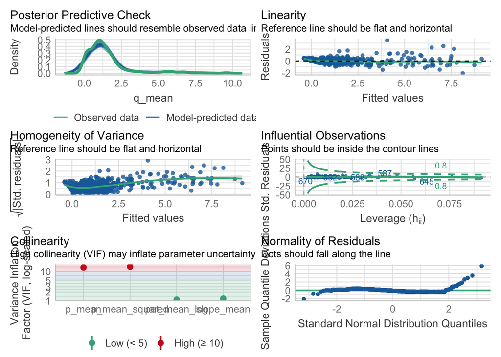

```r
# ok this many predictors is unnecessary. Performance gains are really in the top 4 vars.

# run the narrowed-down model
lm_mod_final <- lm(q_mean ~ p_mean + p_mean_squared + slope_mean + pet_mean_log,
                   data=cq_full)

# check assumptions
check_model(lm_mod_final)
```

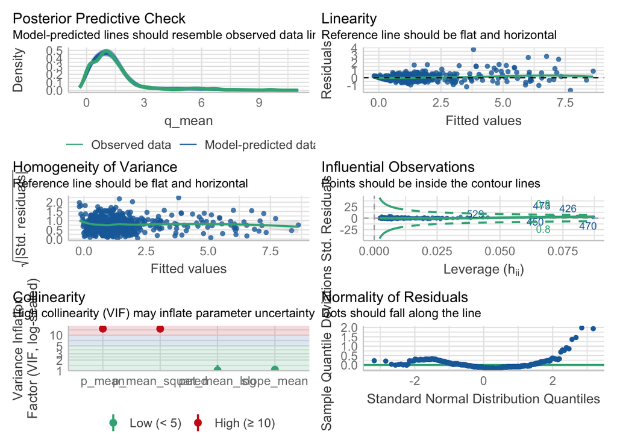

```r
# p_mean and p_mean_squared are correlated... I thought about centering them but decided I didn't know enough about that.

# Also, the residuals don't look normal/the data looks overdispersed. Try weighting the residuals
resid_mod <- lm(abs(lm_mod_final$residuals) ~ lm_mod_final$fitted.values)
modweights <- 1 / resid_mod$fitted.values^2

lm_mod_final_weighted <- lm(q_mean ~ p_mean + p_mean_squared + slope_mean + pet_mean_log,
                    data=cq_full,
                    weights = modweights)

# eh, this doesn't really help. Forget it
check_model(lm_mod_final_weighted)
```

```r
# Every variable seems to contribute to non-normality of residuals, and I haven't found any transformations that help. I'll say phooey and hope RF can solve these problems. But I'll go ahead and interpret the unweighted 4-var model.
summary(lm_mod_final)
```

```
##
## Call:
## lm(formula = q_mean ~ p_mean + p_mean_squared + slope_mean +
##     pet_mean_log, data = cq_full)
##
## Residuals:
##     Min      1Q  Median      3Q     Max
## -2.0780 -0.1898 -0.0314  0.1588  3.5049
##
## Coefficients:
##                  Estimate Std. Error t value Pr(>|t|)
## (Intercept)     1.7126597  0.1783757   9.601  < 2e-16 ***
## p_mean          0.1874181  0.0417192   4.492 8.31e-06 ***
## p_mean_squared  0.0817128  0.0050590  16.152  < 2e-16 ***
## slope_mean      0.0079819  0.0003685  21.659  < 2e-16 ***
## pet_mean_log   -3.8810803  0.2710058 -14.321  < 2e-16 ***
## ---
## Signif. codes:  0 '***' 0.001 '**' 0.01 '*' 0.05 '.' 0.1 ' ' 1
##
## Residual standard error: 0.4127 on 665 degrees of freedom
## Multiple R-squared:  0.9289, Adjusted R-squared:  0.9285
## F-statistic:  2171 on 4 and 665 DF,  p-value: < 2.2e-16
```

> In plain words: Streamflow is higher where there’s more precipitation, a steeper catchment, and less water lost to the atmosphere by evapotranspiration.

## Build a CART model to predict flow.

Linear models help us both predict and understand drivers of change, machine learning can help us understand drivers of change, but as a technique it is more suited to accurate predictions. CART or Classification and Regression Trees are a nice intermediate between lms and ml. Tons of resources for this but [CART Logic](https://koalaverse.github.io/machine-learning-in-R/decision-trees.html#cart-software-in-r), provides a good conceptual overview, and [CART demo](https://www.statmethods.net/advstats/cart.html) provides a good enough code demo.

Read the logic intro above, and the code demo as well, to build a CART model version of your lm. Use the code to visualize your CART output.

```r
# let's bin the q_means to start
cq_binned <- cq_full %>%
  mutate(q_mean_bin = cut_number(cq_full$q_mean, n=4)) %>%
  select(-q_mean)

# 70/30 split
train <- sample_frac(cq_binned, 0.7)
test <- anti_join(cq_binned, train)
```

[output not shown]

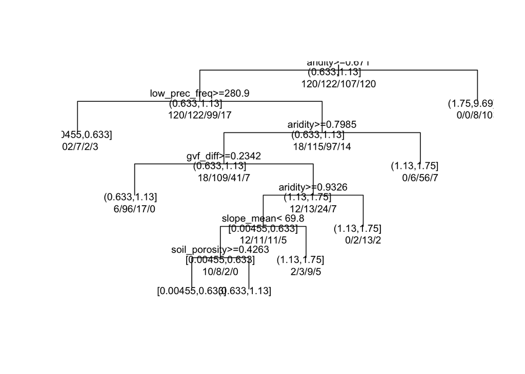

```r
# build the tree on the training data
cart_simple <- rpart(q_mean_bin ~ .,
                  method="class",
                  data=train,
                  cp=0.01) # this will make a pretty complex model

# plot tree
plot(cart_simple, uniform=TRUE)
text(cart_simple, use.n=TRUE, all=TRUE, cex=.8)
```

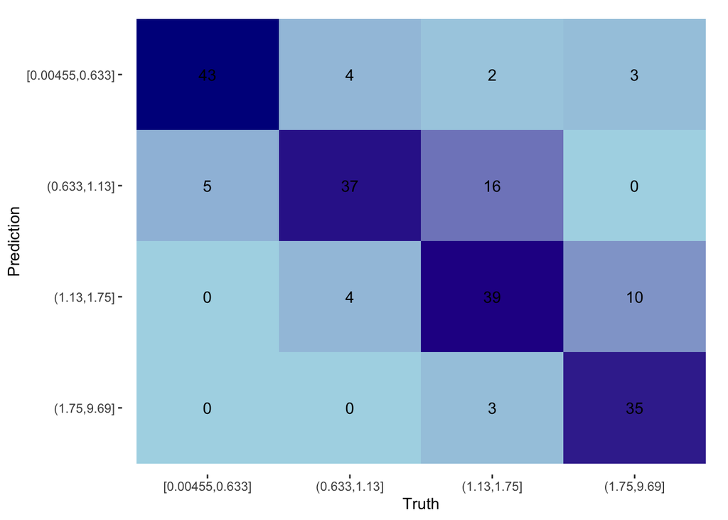

```r
# predict over the testing data
test$pred <- predict(cart_simple, test, 'class')

# evaluate test accuracy
cm <- conf_mat(data=test, truth=q_mean_bin, estimate=pred)

autoplot(cm, type='heatmap') +
  scale_fill_gradient(low='lightblue', high='darkblue')
```

```r
accuracy(test, q_mean_bin, pred)
```

```
## # A tibble: 1 × 3
##   .metric  .estimator .estimate
##   <chr>    <chr>          <dbl>
## 1 accuracy multiclass     0.766
```

Ooook so testing accuracy is 77%. Not bad! And the errors are pretty well-dispersed throughout the classes.

## Build a RandomForest

CARTs are a single tree, what if we had thousands? Would we get better performance (yes!)

The same CART logic site above introduces random forests as well. Please read this part of the site and use the code demo to build your own RandomForest. Remember, for a RandomForest type model we want to make sure we split our data at least into train and test datasets and ideally into train-test-val.